# wk9-1_데이터마이닝과 예측

choi

2020 10 6

```r
library(tidyverse)
library(modelr)
library(ggplot2)
library(car)
```

# 다중회귀분석1

1. 데이터마이닝
- 데이터마이닝, 통계모델, 기계학습, 인공지능…
- Supervised learning, Unsupervied learning

## 1.데이터 마이닝 기법

데이터 마이닝 : 예측 -> 회귀분석, 선형모형, 비선형모형  
분류 -> 의사결정나무, 서포트백터 머신,판별분석, 로지스틱회귀모형

# set working directory

setwd(“C:\Users\user\Desktop\class_R\data mining\data”)

# autompg data

```r
car<-read.csv(file.choose())
head(car)
```

```
##   mpg cyl disp hp   wt accler year origin                   carname
## 1  18   8  307 17 3504   12.0   70      1 chevrolet chevelle malibu
## 2  15   8  350 35 3693   11.5   70      1         buick skylark 320
## 3  18   8  318 29 3436   11.0   70      1        plymouth satellite
## 4  16   8  304 29 3433   12.0   70      1             amc rebel sst
## 5  17   8  302 24 3449   10.5   70      1               ford torino
## 6  15   8  429 42 4341   10.0   70      1          ford galaxie 500
```

```r
str(car)
```

```
## 'data.frame':    398 obs. of  9 variables:
##  $ mpg    : num  18 15 18 16 17 15 14 14 14 15 ...
##  $ cyl    : int  8 8 8 8 8 8 8 8 8 8 ...
##  $ disp   : num  307 350 318 304 302 429 454 440 455 390 ...
##  $ hp     : int  17 35 29 29 24 42 47 46 48 40 ...
##  $ wt     : int  3504 3693 3436 3433 3449 4341 4354 4312 4425 3850 ...
##  $ accler : num  12 11.5 11 12 10.5 10 9 8.5 10 8.5 ...
##  $ year   : int  70 70 70 70 70 70 70 70 70 70 ...
##  $ origin : int  1 1 1 1 1 1 1 1 1 1 ...
##  $ carname: chr  "chevrolet chevelle malibu" "buick skylark 320" "plymouth satellite" "amc rebel sst" ...
```

```r
attach(car)
```

## 2.다중회귀분석

- 다중회귀모형 : lm(y변수~x1+x2+x3, data= )

# multiple regression : 1st full model

```r
r1<-lm(mpg ~ disp+hp+wt+accler, data=car)
summary(r1)
```

```
##
## Call:
## lm(formula = mpg ~ disp + hp + wt + accler, data = car)
##
## Residuals:
##      Min       1Q   Median       3Q      Max
## -11.8331  -2.8735  -0.3164   2.4449  16.2079
##
## Coefficients:
##               Estimate Std. Error t value Pr(>|t|)
## (Intercept) 40.8838025  1.9966258  20.476  < 2e-16 ***
## disp        -0.0106291  0.0065254  -1.629   0.1041
## hp           0.0047774  0.0082597   0.578   0.5633
## wt          -0.0061405  0.0007449  -8.243 2.54e-15 ***
## accler       0.1722165  0.0976340   1.764   0.0785 .
## ---
## Signif. codes:  0 '***' 0.001 '**' 0.01 '*' 0.05 '.' 0.1 ' ' 1
##
## Residual standard error: 4.298 on 393 degrees of freedom
## Multiple R-squared:  0.7006, Adjusted R-squared:  0.6976
## F-statistic:   230 on 4 and 393 DF,  p-value: < 2.2e-16
```

- 선형회귀식 mpg = 40.88 - 0.011 disp + 0.0048 hp - 0.0061 wt + 0.17 accler
- 선형 회귀식의 결정계수 R2=0.7006
- 다중회귀모형: 데이터탐색 # pariwise plot - Explanatory Data Analysis

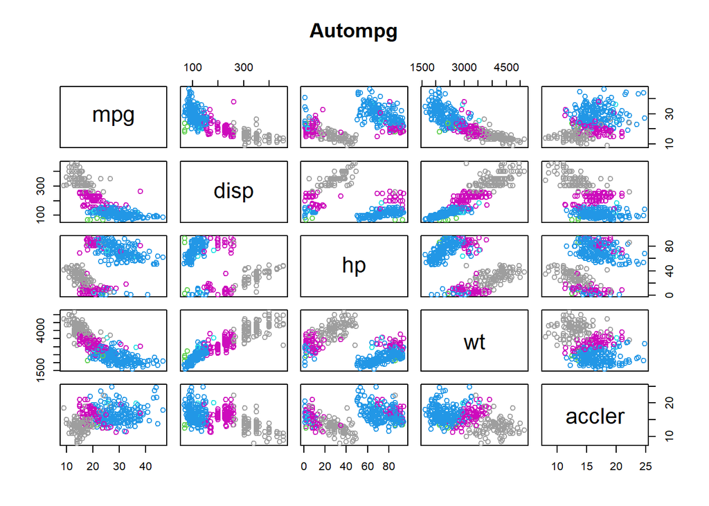

```r
var1<-c("mpg","disp","hp","wt", "accler" )
pairs(car[var1], main ="Autompg",cex=1, col=as.integer(car$cyl))
```

# 3 다중회귀분석 - 변수선택방벙

- 변수선택방법 – 다수의 독립변수들이 있을때 최종모형은?
1. 전진선택법(forward selection) - 독립변수중에서 종속변수에 가장 큰 영향을 주는 변수부터 모형에 포함
2. 후진제거법(backward elimination) -독립변수를 모두 포함한 모형에서 가장 영향이적은(중요하지 않은) 변수부터 제거
3. 단계별 방법(stepwise method) -전진선택법에 의해 변수 추가 -변수 추가시 기존 변수의 중요도가 정해진 유의수준(threshold)에 포함되지 않으면 앞에서 들어간 변수도 다시 제거됨

```
단계별방법의 예제
모형에 포함되는 유의수준(0.15)
모형에서 제거되는 유의수준(0.15)
step1 : x4 (p-value=0.01)
step2: x4 (0.01), x10 (0.03)
step3: x4 (0.01), x10 (0.2), x2 (0.12)
step4: x4, x2
step5: x4, x2, x5
```

- 단계별 방법(stepwise method) -step(모형, direction=“both”)

# 2rd model using variable selection method

# step(r1, direction=“forward”)

# step(r1, direction=“backward”)

# stepwise selection

```r
step(r1, direction="both")
```

```
## Start:  AIC=1165.67
## mpg ~ disp + hp + wt + accler
##
##          Df Sum of Sq    RSS    AIC
## - hp      1      6.18 7266.2 1164.0
## <none>                7260.0 1165.7
## - disp    1     49.01 7309.1 1166.3
## - accler  1     57.48 7317.5 1166.8
## - wt      1   1255.16 8515.2 1227.1
##
## Step:  AIC=1164.01
## mpg ~ disp + wt + accler
##
##          Df Sum of Sq    RSS    AIC
## <none>                7266.2 1164.0
## - disp    1     51.76 7318.0 1164.8
## - accler  1     58.62 7324.8 1165.2
## + hp      1      6.18 7260.0 1165.7
## - wt      1   1291.30 8557.5 1227.1
```

```
##
## Call:
## lm(formula = mpg ~ disp + wt + accler, data = car)
##
## Coefficients:
## (Intercept)         disp           wt       accler
##   41.299076    -0.010895    -0.006189     0.173851
```

#step(lm(mpg ~ disp+hp+wt+accler, data=car), direction=“both”)

- 단계별 방법에 따른 최종 다중회귀모형

# final multiple regression

```r
r2<-lm(mpg ~ disp+wt+accler, data=car)
summary(r2)
```

```
##
## Call:
## lm(formula = mpg ~ disp + wt + accler, data = car)
##
## Residuals:
##      Min       1Q   Median       3Q      Max
## -11.7382  -2.8112  -0.3607   2.5231  16.1845
##
## Coefficients:
##               Estimate Std. Error t value Pr(>|t|)
## (Intercept) 41.2990756  1.8614975  22.186  < 2e-16 ***
## disp        -0.0108953  0.0065036  -1.675   0.0947 .
## wt          -0.0061889  0.0007396  -8.368 1.03e-15 ***
## accler       0.1738507  0.0975107   1.783   0.0754 .
## ---
## Signif. codes:  0 '***' 0.001 '**' 0.01 '*' 0.05 '.' 0.1 ' ' 1
##
## Residual standard error: 4.294 on 394 degrees of freedom
## Multiple R-squared:  0.7004, Adjusted R-squared:  0.6981
## F-statistic:   307 on 3 and 394 DF,  p-value: < 2.2e-16
```

```
선형회귀식
mpg = 41.30 - 0.011 disp- 0.0062 wt + 0.17 accler

선형회귀식의 결정계수
R2=0.7004
```

# residual diagnostic plot

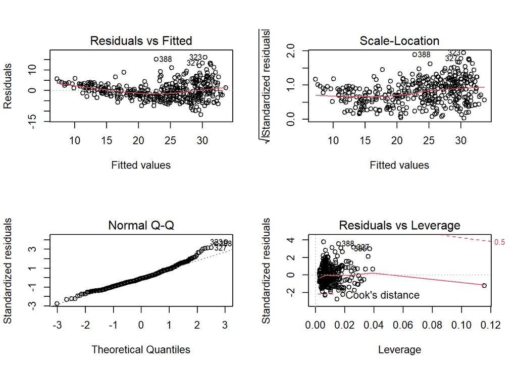

```r
layout(matrix(c(1,2,3,4),2,2)) # optional 4 graphs/page
plot(r2)
```